# Building Data Pipelines with BigQuery and Python

An Overview

python

sql

Author

Jesus L. Monroy

Published

May, 2024

Abstract

In the realm of data analytics, Extract, Transform, Load (ETL) processes play a pivotal role.  
They streamline the integration of data from various sources, enabling its cleaning, manipulation, and loading into target systems like BigQuery, Google’s cloud-based data warehouse.  
By leveraging Python’s versatility and BigQuery’s scalability, you can construct powerful ETL pipelines to prepare your data for insightful analysis.

[figure not shown]

### Environment settings

```python
# Import libraries
import numpy as np
import pandas as pd
import polars as pl
import gspread
import duckdb
import sqlalchemy as db
import pyodbc
from oauth2client.service_account import ServiceAccountCredentials
from google.oauth2 import service_account
from google.cloud import bigquery
import connectorx as cx
import warnings
warnings.filterwarnings('ignore')
```

```python
scopes = ['https://www.googleapis.com/auth/spreadsheets',
        'https://www.googleapis.com/auth/drive',
        'https://www.googleapis.com/auth/analytics.readonly']

# Read google credentials
api = 'creds.json'

# connect to google sheets
gs_credentials = ServiceAccountCredentials.from_json_keyfile_name(api, scopes)
gc = gspread.authorize(gs_credentials)

# connect to big query
bq_credentials = service_account.Credentials.from_service_account_file(api)
project_id = 'repository'
client = bigquery.Client(credentials=bq_credentials,project=project_id)
```

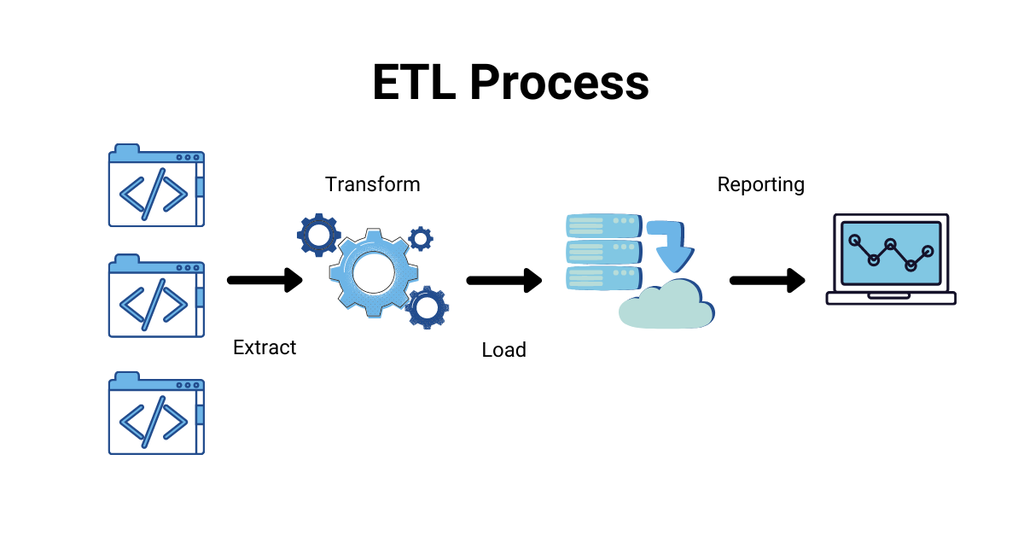

Figure 1: ETL Diagram

## Extract Phase

The extraction phase entails retrieving data from your source. This may involve interacting with:

- Flat files
- Databases
- XML files
- APIs
- Other

### Flat files

```python
users = (
    pl.read_csv('users.csv', dtypes={'phone': pl.Utf8, 'id_atg':pl.Utf8})
    .with_columns(
        pl.col('entry_data').str.strptime(pl.Datetime, strict=False)
    )
)
```

```python
users_profiling = (
    # read csv file
    pl.read_csv('profiles.csv', dtypes={'contact_phone': pl.Utf8,'post_code':pl.Utf8})
        # change column dtypes
    .with_columns(
        pl.col('entry_data','entry_data_gep','update_date').str.strptime(pl.Datetime, strict=False),
        pl.col('contact_phone').cast(pl.Utf8),
    )
)
```

```python
orders = (
    pl.read_csv('orders.csv').with_columns(
        pl.col('entry_date','delivery_date').str.strptime(pl.Datetime, strict=False)
    )
)
```

```python
order_details = (
    pl.read_csv('order-details.csv')
)
```

```python
promotions = (
    pl.read_csv('promotions.csv', dtypes={'short_description':pl.Utf8})
    .with_columns(pl.col('key').cast(pl.Utf8))
).unique(subset='key')
```

```python
order_status = pl.read_csv('order-status.csv')
```

```python
social_networks = (
    pl.read_csv('social_networks.csv').select(
        pl.col('id_social_network','social_network','description')
    )
)
```

### Parquet files

```python
types = pl.read_parquet('types.parquet')
```

```python
genre = pl.read_parquet('genre.parquet')
```

### json files

```python
warehouses = pl.read_json('warehuse_catalog.json')
```

### Databases

```python
# Connection to MS Access
conn = pyodbc.connect(r'DRIVER={Microsoft Access Driver (*.mdb, *.accdb)};'r'DBQ=C:\Users\user\folder\file.accdb;')
# Create cursor
cursor = conn.cursor()
```

```python
# Write query
query = 'select * from sales where year=2022'
# Convert to pandas dataframe
df = pd.read_sql(query, con=conn)
df.head()
```

[output not shown]

## Transform Phase

Cleanse, validate, and manipulate the extracted data based on your analysis requirements. This might include:

- **Data Cleaning**

Handle missing values, inconsistent formatting, or errors.

- **Data Type Conversion**

Ensure consistent data types for columns based on their intended use in BigQuery.

- **Filtering/Aggregation**

Select or aggregate specific data subsets for targeted analysis.

- **Enrichment**

Merge extracted data with additional sources to enhance its value.

```python
# join types, orders, order_details, promotions and warehouses
sheet = (
    types.join(orders, on='id_type', how='left')
    .join(order_details, on='id_order', how='left')
    .join(promotions, on='key', how='left')
    .join(warehouses, on='id_warehouse', how='left')
).rename({'id_warehouse':'id_warehouse_promo', 'active':'promo_active'})
```

## Load Phase

There are two primary options for loading data:

- **Staging Table**

Create a staging table and load the transformed data into it for temporary storage before validating and potentially modifying it:

- **Direct Load**

Load the data directly into your target table, bypassing the staging step. However, this approach can be less flexible for complex transformations:

```python
# create dataset
client.create_dataset('database')
```

```
Dataset(DatasetReference('gepp-538', 'database'))
```

```python
# convert to pandas
sheet = sheet.to_pandas()
# upload to big query
sheet.to_gbq('dw.transformation.catalog',
                    project_id='repository-538',
                    if_exists='replace',
                    credentials=bq_credentials)
```

## Execute queries from Big Query

```python
# create sql query
query = '''
    SELECT *
    FROM `dw.transformation.catalog`
'''
# convert query to pandas dataframe
catalog = pd.read_gbq(query, credentials=bq_credentials)
```

## Contact

**Jesus L. Monroy**  
*Economist & Data Scientist*

[Medium](https://medium.com/@jesuslm) | [Linkedin](https://www.linkedin.com/in/j3sus-lm) | [Twitter](https://x.com/j3suslm)